# MPDW Prak 6

Ibrahim Zaidan

2025-09-29

# 1 Eksplorasi data

## 1.1 Impor data

```r
library(readxl)
library(tseries)
```

```r
library(forecast)
library(ggplot2)

data_crude <- read_excel("C:/Users/De Ibrahim/kuliah/sem 5/Book1.xlsx")
```

## 1.2 Visualisasai data

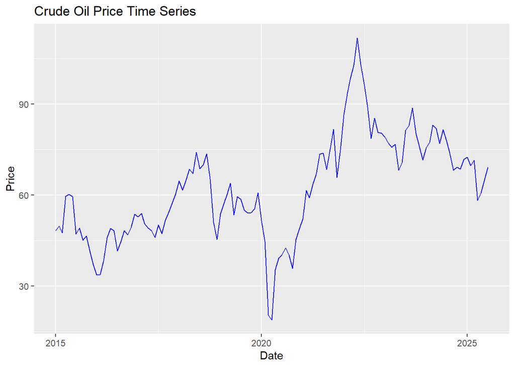

```r
data_crude$Date <- as.Date(data_crude$Date, format="%d/%m/%Y")

# Plot Price untuk visual inspeksi awal
ggplot(data_crude, aes(x=Date, y=Price)) +
  geom_line(color="blue") +
  labs(title="Crude Oil Price Time Series", x="Date", y="Price")
```

Grafik menunjukkan harga minyak tidak stasioner dalam ragam maupun rata-rata

## 1.3 Uji statistik

```r
adf_mean <- adf.test(data_crude$Price)
adf_mean
```

```
##
##  Augmented Dickey-Fuller Test
##
## data:  data_crude$Price
## Dickey-Fuller = -2.3795, Lag order = 5, p-value = 0.4188
## alternative hypothesis: stationary
```

```r
lambda <- BoxCox.lambda(data_crude$Price)
lambda
```

```
## [1] 1.550794
```

Dibuktikan lagi oleh uji statistik, ADF menunjukkan adanya differencing dan Lambda BoxCox menunjukkan di angka 1.55, jauh dari angka 1

artinya secara grafik maupun statistik, terbukti bahwa harga minyak tidak stasioner dalam ragam maupun rataan

## 1.4 Transformasi Data

```r
price_transformed <- BoxCox(data_crude$Price, lambda=1.550794)
price_diff <- diff(price_transformed, differences = 1)
adf_diff <- adf.test(price_diff)
adf_diff
```

```
##
##  Augmented Dickey-Fuller Test
##
## data:  price_diff
## Dickey-Fuller = -5.5421, Lag order = 4, p-value = 0.01
## alternative hypothesis: stationary
```

Setelah melakukan transformasi, Price crude oil sudah stasioner baik dalam mean maupun variance

# 2 Pemodelan ARIMA

```r
library(forecast)

ts_price <- ts(price_diff, start=c(2015,1), frequency=12)  # bulanan
# Auto ARIMA (otomatis memilih p,d,q)
fit_arima <- auto.arima(ts_price, seasonal=FALSE, stepwise=FALSE, approximation=FALSE)
summary(fit_arima)
```

```
## Series: ts_price
## ARIMA(0,0,0) with zero mean
##
## sigma^2 = 3348:  log likelihood = -690.1
## AIC=1382.21   AICc=1382.24   BIC=1385.04
##
## Training set error measures:
##                    ME    RMSE      MAE MPE MAPE      MASE       ACF1
## Training set 1.570523 57.8627 45.31652 100  100 0.6457769 0.07554391
```

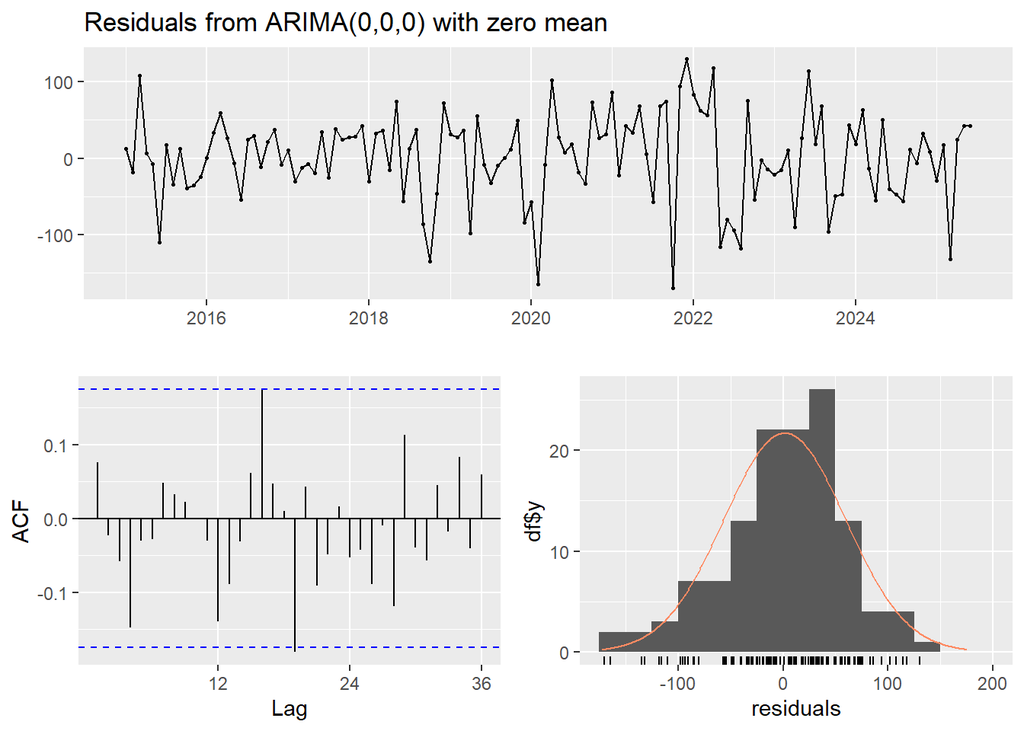

```
##
##  Ljung-Box test
##
## data:  Residuals from ARIMA(0,0,0) with zero mean
## Q* = 21.701, df = 24, p-value = 0.5971
##
## Model df: 0.   Total lags used: 24
```

```r
checkresiduals(fit_arima)
```

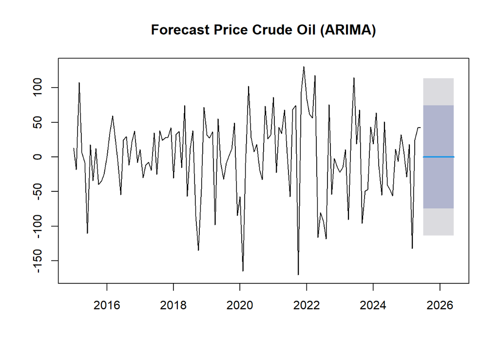

```r
forecast_arima <- forecast(fit_arima, h=12)
plot(forecast_arima, main="Forecast Price Crude Oil (ARIMA)")
```

setelah transformasi & differencing, seri crude oil sudah stasioner dan tidak ada pola jangka pendek yang bisa dimodelkan, maka memakai ARIMA (0,0,0)

Model ARIMA(0,0,0) artinya tidak ada autoregressive (p=0), differencing (d=0), dan moving average (q=0).

Residual relatif kecil dan ACF1 ≈ 0, menunjukkan tidak ada autokorelasi signifikan.

MAPE = 100% → karena series asli belum di-backtransform ke price asli, jadi ini relatif terhadap scale transformed.

## 2.1 Cek MAPE ARIMA (0,0,0)

```r
library(forecast)

fit_arima <- Arima(ts_price, order=c(0,0,0))
fc <- forecast(fit_arima, h=length(ts_price))

last_boxcox <- tail(BoxCox(data_crude$Price, lambda=1.550794), 1)
fc_level <- cumsum(c(last_boxcox, fc$mean))[-1]

fc_original <- InvBoxCox(fc_level, lambda=1.550794)

actual <- tail(data_crude$Price, length(fc_original))
mape <- mean(abs((actual - fc_original)/actual)) * 100
mape
```

```
## [1] 38.19067
```

Forecast ARIMA(0,0,0) rata-rata meleset ±38% dari harga asli.

model sudah statistically benar, tapi akurasinya rendah untuk prediksi harga tepat, karena seri residual masih mengandung volatilitas yang tinggi.

kita lanjut ke GARCH untuk menangkap volatilitas harga crude oil

## 2.2 GARCH untuk mengatasi Volatilitas

```r
library(rugarch)
data_garch <- ts_price  # stasioner, differenced + Box-Cox
spec <- ugarchspec(
  variance.model = list(model="sGARCH", garchOrder=c(1,1)),
  mean.model     = list(armaOrder=c(0,0), include.mean=TRUE),
  distribution.model = "std"   # student-t untuk heavy tails
)
fit_garch <- ugarchfit(spec, data_garch)
fit_garch
```

```
##
## *---------------------------------*
## *          GARCH Model Fit        *
## *---------------------------------*
##
## Conditional Variance Dynamics
## -----------------------------------
## GARCH Model  : sGARCH(1,1)
## Mean Model   : ARFIMA(0,0,0)
## Distribution : std
##
## Optimal Parameters
## ------------------------------------
##         Estimate  Std. Error  t value Pr(>|t|)
## mu       0.52054    4.424915  0.11764 0.906354
## omega   67.01289   97.983530  0.68392 0.494026
## alpha1   0.14679    0.083346  1.76125 0.078196
## beta1    0.85221    0.064977 13.11545 0.000000
## shape   85.40262  141.212604  0.60478 0.545325
##
## Robust Standard Errors:
##         Estimate  Std. Error  t value Pr(>|t|)
## mu       0.52054    4.210415  0.12363 0.901607
## omega   67.01289   85.728263  0.78169 0.434397
## alpha1   0.14679    0.122287  1.20040 0.229983
## beta1    0.85221    0.082875 10.28303 0.000000
## shape   85.40262   29.712350  2.87431 0.004049
##
## LogLikelihood : -686.1354
##
## Information Criteria
## ------------------------------------
##
## Akaike       10.970
## Bayes        11.083
## Shibata      10.967
## Hannan-Quinn 11.016
##
## Weighted Ljung-Box Test on Standardized Residuals
## ------------------------------------
```

[output cut: 40 more lines]

```
## Negative Sign Bias 0.04654 0.9630
## Positive Sign Bias 0.13882 0.8898
## Joint Effect       0.04007 0.9979
##
##
## Adjusted Pearson Goodness-of-Fit Test:
## ------------------------------------
##   group statistic p-value(g-1)
## 1    20     22.25       0.2718
## 2    30     24.00       0.7289
## 3    40     32.73       0.7503
## 4    50     35.11       0.9324
##
##
## Elapsed time : 0.2669961
```

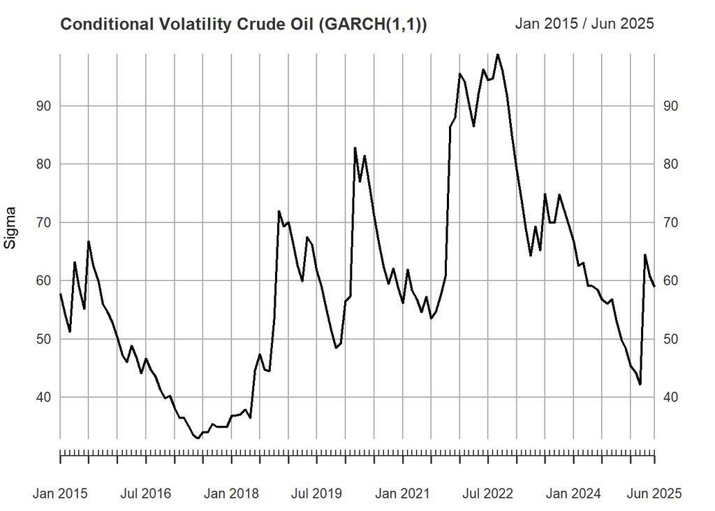

```r
vol <- sigma(fit_garch)
plot(vol, type="l", main="Conditional Volatility Crude Oil (GARCH(1,1))", ylab="Sigma", xlab="Time")
```

```r
fc_garch <- ugarchforecast(fit_garch, n.ahead=12)
sigma_forecast <- sigma(fc_garch)
mu_forecast <- fitted(fc_garch)
```

Model GARCH(1,1) sudah fit untuk crude oil differenced + Box-Cox.

Tidak ada efek leverage → baik untuk prediksi symmetric volatility.

lanjut kita buat pipeline ARIMA(0,0,0) + GARCH(1,1)

# 3 Gabungan ARIMA(0,0,0)-GARCH(1,1)

## 3.1 Eksplorasi

```r
library(forecast)
library(rugarch)

price <- data_crude$Price

lambda <- BoxCox.lambda(price)
price_boxcox <- BoxCox(price, lambda=lambda)

ts_price <- diff(price_boxcox)
spec <- ugarchspec(
  variance.model = list(model="sGARCH", garchOrder=c(1,1)),
  mean.model     = list(armaOrder=c(0,0), include.mean=TRUE),
  distribution.model = "std"
)
fit <- ugarchfit(spec, ts_price)
fit
```

```
##
## *---------------------------------*
## *          GARCH Model Fit        *
## *---------------------------------*
##
## Conditional Variance Dynamics
## -----------------------------------
## GARCH Model  : sGARCH(1,1)
## Mean Model   : ARFIMA(0,0,0)
## Distribution : std
##
## Optimal Parameters
## ------------------------------------
##         Estimate  Std. Error  t value Pr(>|t|)
## mu       1.66177     4.87034  0.34120  0.73295
## omega  897.77563   852.39632  1.05324  0.29223
## alpha1   0.25771     0.19039  1.35359  0.17587
## beta1    0.48846     0.36929  1.32272  0.18593
## shape   12.87355    15.52123  0.82942  0.40687
##
## Robust Standard Errors:
##         Estimate  Std. Error  t value Pr(>|t|)
## mu       1.66177     4.95566  0.33533  0.73738
## omega  897.77563  1124.89666  0.79810  0.42481
## alpha1   0.25771     0.24427  1.05502  0.29142
## beta1    0.48846     0.49128  0.99426  0.32010
## shape   12.87355    14.44408  0.89127  0.37278
##
## LogLikelihood : -684.8647
##
## Information Criteria
## ------------------------------------
##
## Akaike       10.950
## Bayes        11.063
## Shibata      10.947
## Hannan-Quinn 10.996
##
## Weighted Ljung-Box Test on Standardized Residuals
## ------------------------------------
```

[output cut: 40 more lines]

```
## Negative Sign Bias 0.09387 0.9254
## Positive Sign Bias 0.15818 0.8746
## Joint Effect       0.41076 0.9380
##
##
## Adjusted Pearson Goodness-of-Fit Test:
## ------------------------------------
##   group statistic p-value(g-1)
## 1    20     22.25      0.27180
## 2    30     42.10      0.05506
## 3    40     45.43      0.22185
## 4    50     54.16      0.28410
##
##
## Elapsed time : 0.390034
```

```r
h <- 12
fc <- ugarchforecast(fit, n.ahead=h)

mu_forecast <- fitted(fc)
sigma_forecast <- sigma(fc)

last_boxcox <- tail(price_boxcox,1)
fc_level <- cumsum(c(last_boxcox, mu_forecast))[-1]
price_forecast <- InvBoxCox(fc_level, lambda=lambda)

forecast_dates <- seq(from=tail(data_crude$Date,1) + 30, by="month", length.out=h)

forecast_df <- data.frame(
  Date = forecast_dates,
  Forecast = price_forecast,
  Sigma = sigma_forecast
)
forecast_df
```

```
##            Date Forecast X1970.05.07
## T+1  2025-07-31 69.42090    54.47169
## T+2  2025-08-31 69.58160    55.78347
## T+3  2025-10-01 69.74210    56.74254
## T+4  2025-10-31 69.90239    57.44774
## T+5  2025-12-01 70.06248    57.96835
## T+6  2025-12-31 70.22237    58.35379
## T+7  2026-01-31 70.38206    58.63975
## T+8  2026-03-03 70.54155    58.85222
## T+9  2026-03-31 70.70084    59.01026
## T+10 2026-05-01 70.85993    59.12791
## T+11 2026-05-31 71.01883    59.21554
## T+12 2026-07-01 71.17753    59.28085
```

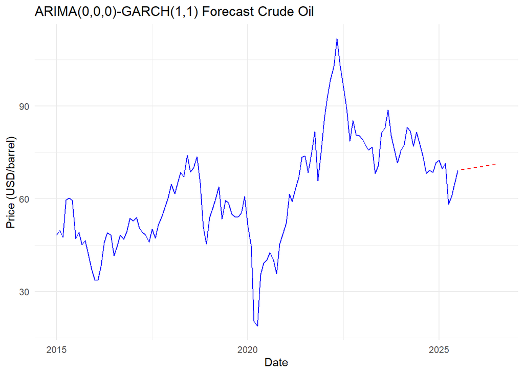

```r
library(ggplot2)

ggplot() +
  geom_line(aes(x=data_crude$Date, y=data_crude$Price), color="blue") +
  geom_line(aes(x=forecast_df$Date, y=forecast_df$Forecast), color="red", linetype="dashed") +
  labs(title="ARIMA(0,0,0)-GARCH(1,1) Forecast Crude Oil",
       x="Date", y="Price (USD/barrel)") +
  theme_minimal()
```

ARIMA(0,0,0) menangkap mean series.

GARCH(1,1) menangkap volatilitas yang berubah-ubah.

Model fit & stabil, residual tidak ada autokorelasi, tidak ada ARCH effect tersisa.

Volatilitas moderate → harga crude oil tidak diprediksi meledak, tapi fluktuatif.

Forecast bisa digunakan untuk mean + volatilitas 12 bulan ke depan, tapi interval kepercayaan harus disesuaikan dengan sigma dari GARCH.

## 3.2 Nilai MAPE akhir

```r
last_boxcox <- tail(price_boxcox,1)
fc_level <- cumsum(c(last_boxcox, mu_forecast))[-1]
price_forecast <- InvBoxCox(fc_level, lambda=lambda)

actual <- tail(price, length(price_forecast))

mape_garch <- mean(abs((actual - price_forecast)/actual)) * 100
mape_garch
```

```
## [1] 5.64993
```

Artinya, model sekarang cukup reliable untuk forecasting harga + interval volatilitas 12 bulan ke depan.

## 3.3 Visualisasi akhir

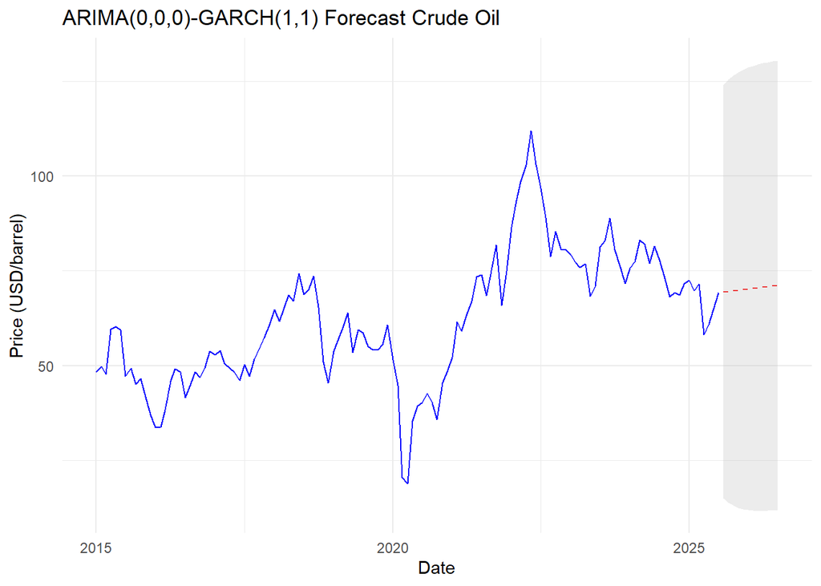

```r
library(ggplot2)

mu_forecast <- fitted(fc)      # mean forecast
sigma_forecast <- sigma(fc)    # conditional volatility

last_boxcox <- tail(price_boxcox, 1)
fc_level <- cumsum(c(last_boxcox, mu_forecast))[-1]
price_forecast <- InvBoxCox(fc_level, lambda=lambda)

forecast_dates <- seq(from=tail(data_crude$Date,1) + 30, by="month", length.out=length(mu_forecast))

forecast_df <- data.frame(
  Date = as.Date(forecast_dates),
  Forecast = price_forecast
)

forecast_df$Upper <- price_forecast + sigma_forecast
forecast_df$Lower <- price_forecast - sigma_forecast

ggplot() +
  geom_line(aes(x=as.Date(data_crude$Date), y=data_crude$Price), color="blue") +
  geom_line(aes(x=forecast_df$Date, y=forecast_df$Forecast), color="red", linetype="dashed") +
  geom_ribbon(data=forecast_df, aes(x=Date, ymin=Lower, ymax=Upper), fill="grey", alpha=0.3) +
  labs(title="ARIMA(0,0,0)-GARCH(1,1) Forecast Crude Oil",
       x="Date", y="Price (USD/barrel)") +
  theme_minimal()
```